# Prior Predictive Exploration - Subgroups model

```r
# Load/install required packages
pacman::p_load(cmdstanr,
               tidyverse,
               bayesplot,
               posterior,
               rio,
               data.table,
               here,
               ggdist)
```

# Overview

This document explains a Bayesian hierarchical meta-analysis model implemented in Stan for analyzing binomial data from multiple studies, accounting for studies with no events (zero inflation). The model estimates fixed effects for treatment and control groups, incorporates study-specific random effects, and models excess zeros using a zero-inflation component.

This model takes into account the population heterogeneity. Specifically, we assume that the event probability in a certain study subpopulation, referred to as a “healthy population”, is extremely low, approximately equal to zero. In contrast, we assume the other subpopulation, referred to as a “sicker population”, has a relatively high event probability. We denote **pi** as the proportion of studies with healthy populations representing individuals who have approximately zero risk for the event of interest.

# Data Structure

# Model Parameters

The model includes the following parameters:

- **mu[1]** and **mu[2]**: Fixed effects for the log-odds of success in the control (`mu[1]`) and treatment (`mu[2]`) groups.
- **sigma_nu[1]** and **sigma_nu[2]**: Standard deviations for the random effects of control and treatment groups.
- **omega_nu**: A 2x2 correlation matrix for the random effects, capturing correlations between treatment and control random effects.
- **nu[J,2]**: Study-specific random effects for control (`nu[n,1]`) and treatment (`nu[n,2]`) groups for each study `n`.
- **pi**: The proportion of studies with healthy populations representing individuals who have approximately zero risk for the event of interest.
- beta[1] and beta[2]: Coefficients for the subgroup effect on the log-odds of success in the control (beta[1]) and treatment (beta[2]) groups, adjusting the baseline fixed effects for studies where subgroup = 1. The adjusted fixed effect for study n is mu_base[i] + beta[i] * subgroup[n] for i = 1 (control) or i = 2 (treatment).

## Priors

The priors are specified as follows:

- Random effects: ($\nu_n \sim \text{MultiNormal}(0, \Sigma_\nu)$), where $\Sigma_\nu = \text{diag}(\sigma_\nu) \Omega_\nu \text{diag}(\sigma_\nu)$.
- Standard deviations: ($\sigma_\nu \sim \text{Half-Normal}(0.5)$).
- Correlation matrix: ($\Omega_\nu \sim \text{LKJ}(2.0)$).
- Fixed effects: ($\mu \sim \text{Normal}(0, 2)$).
- Zero-inflation probability: $\pi \sim \text{Beta}(1, 1)$.

# Data

```r
dat = import(here("data/raw_data.xlsx"))

setnames(dat, old=c("Int_Events","Control_Events"), new=c("r2", "r1"))
setnames(dat, old=c("Int_Total","Control_Total"), new=c("n2", "n1"))


# Prepare data for Stan (only J, zero, and sample are needed)
J <- nrow(dat)  # Number of studies (84)
zero <- c(0, 0)  # Zero vector for random effects mean
sample <- as.matrix(dat[, c("n1", "n2")])  # Sample sizes: control (n1), treatment (n2)
subgroup <- dat[, "Low_Dose"]

# Create the Stan data list
stan_data <- list(
  J = J,
  zero = zero,
  sample = sample,
  subgroup = subgroup
)
```

# Model

```r
# Write and compile the model
model1 <- cmdstan_model(here("models/stan/zibglmm_subgroups_prior_model1.stan"))
```

```r
csv_files <- list.files(here("models/storage"),
                        pattern = "^zibglmm_subgroups_prior_model1.*\\.csv$",
                        full.names = TRUE)

if (length(csv_files) > 0 && all(file.exists(csv_files))) {
  # Load the fit from CSV files
  fit_prior_mod <- cmdstanr::as_cmdstan_fit(csv_files)

} else {
  # Fit the model if no CSV files are found
  fit_prior_mod <- model1$sample(
    data = stan_data,
    chains = 4,
    parallel_chains = 4,
    iter_warmup = 2000,
    iter_sampling = 2000,
    adapt_delta = 0.99,
    seed = 123,
    refresh = 0
  )

  # Save CSV files to persistent directory
  fit_prior_mod$save_output_files(dir = "models/storage")
}
```

# Prior Predictive Checking

## Parameters

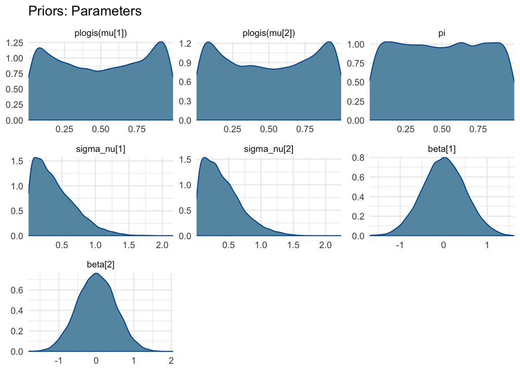

```r
prior_draws_parameters_mod <-
  fit_prior_mod$draws(variables = c("mu", "pi", "sigma_nu", "beta"),
                           format = "df")

# Transform mu[1] and mu[2] using plogis()
mu1_prob <- plogis(prior_draws_parameters_mod$`mu[1]`)
mu2_prob <- plogis(prior_draws_parameters_mod$`mu[2]`)

# Combine transformed mu draws with pi into a new matrix
transformed_draws_mod <- matrix(c(mu1_prob,
                              mu2_prob,
                              prior_draws_parameters_mod$pi,
                              prior_draws_parameters_mod$`sigma_nu[1]`,
                              prior_draws_parameters_mod$`sigma_nu[2]`,
                              prior_draws_parameters_mod$`beta[1]`,
                              prior_draws_parameters_mod$`beta[2]`),
                            ncol = 7,
                            dimnames = list(NULL, c("plogis(mu[1])",
                                                    "plogis(mu[2])",
                                                    "pi",
                                                    "sigma_nu[1]",
                                                    "sigma_nu[2]",
                                                    "beta[1]",
                                                    "beta[2]")))

# Density plot for transformed mu and pi
mcmc_dens(transformed_draws_mod,
          pars = c("plogis(mu[1])",
                   "plogis(mu[2])",
                   "pi",
                   "sigma_nu[1]",
                   "sigma_nu[2]",
                   "beta[1]",
                   "beta[2]")
          ) +
  ggtitle("Priors: Parameters") +
  theme_minimal()
```

## Estimands

```r
# Extract prior predictive draws
prior_draws_estimands <-
  fit_prior_mod$draws(variables =
                        c("p_control_sub0",
                          "p_control_sub1",
                          "p_treatment_sub0",
                          "p_treatment_sub1",
                          "RR_sub0",
                          "RR_sub1",
                          "OR_sub0",
                          "OR_sub1",
                          "RD_sub0",
                          "RD_sub1"),
                  format = "df")
```

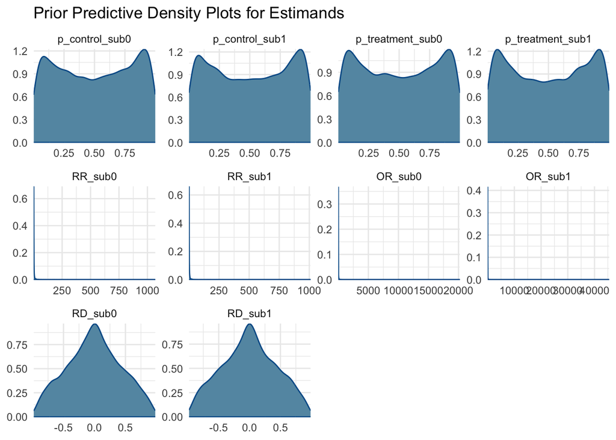

```r
# 2. Density Plots for Estimands
mcmc_dens(prior_draws_estimands,
          pars = c("p_control_sub0",
                   "p_control_sub1",
                   "p_treatment_sub0",
                   "p_treatment_sub1",
                   "RR_sub0",
                   "RR_sub1",
                   "OR_sub0",
                   "OR_sub1",
                   "RD_sub0",
                   "RD_sub1")
            ) +
  ggtitle("Prior Predictive Density Plots for Estimands") +
  theme_minimal()
```

## Predictive Analysis

For the prior predictive checks, we recommend aiming for a prior data-generating process that can produce plausible data sets, not necessarily data sets that are indistinguishable from observed data.

```r
# Extract draws from the prior predictive fit
draws <- fit_prior_mod$draws(format = "df")

# Determine the number of samples and studies
n_samples <- nrow(draws)  # Total draws after warmup
J <- nrow(dat)  # Number of studies (adjust based on your data)

# Extract mu_base, beta, and nu from draws
mu_control <- draws$`mu[1]`
mu_treatment <- draws$`mu[2]`
beta_control <- draws$`beta[1]`
beta_treatment <- draws$`beta[2]`

# Extract the subgroup covariate (ensure this matches your data)
subgroup <- dat$Low_Dose  # Binary vector (0 or 1) for each study

# Initialize matrices for study-specific probabilities
p_control_n <- matrix(NA, nrow = n_samples, ncol = J)
p_treatment_n <- matrix(NA, nrow = n_samples, ncol = J)

# Compute study-specific probabilities, adjusted for subgroup
for (j in 1:J) {
  nu_control_j <- draws[[paste0("nu[", j, ",1]")]]
  nu_treatment_j <- draws[[paste0("nu[", j, ",2]")]]

  # Adjust fixed effects for subgroup
  p_control_n[, j] <- plogis(mu_control + beta_control * subgroup[j] + nu_control_j)
  p_treatment_n[, j] <- plogis(mu_treatment + beta_treatment * subgroup[j] + nu_treatment_j)
}

# Reshape data into long format, including subgroup information
control_long <- data.frame(
  Probability = as.vector(p_control_n),
  Study = factor(rep(1:J, each = n_samples)),
  Group = "Control",
  Subgroup = factor(rep(subgroup, each = n_samples), levels = c(0, 1), labels = c("Subgroup 0", "Subgroup 1"))
)

treatment_long <- data.frame(
  Probability = as.vector(p_treatment_n),
  Study = factor(rep(1:J, each = n_samples)),
  Group = "Treatment",
  Subgroup = factor(rep(subgroup, each = n_samples), levels = c(0, 1), labels = c("Subgroup 0", "Subgroup 1"))
)
```

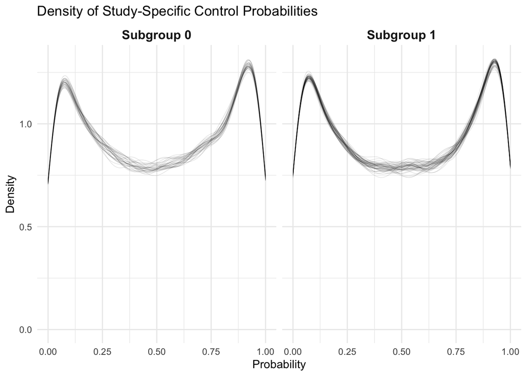

```r
ggplot(control_long, aes(x = Probability, group = Study)) +
  geom_density(alpha = 0.01, linewidth = 0.03) +
  labs(title = "Density of Study-Specific Control Probabilities",
       x = "Probability",
       y = "Density") +
  theme_minimal() +
  scale_y_continuous(limits = c(0, NA)) +  # Ensure y-axis starts at 0
  facet_wrap(~Subgroup, ncol = 2) +
  theme(strip.text = element_text(size = 12, face = "bold"))
```

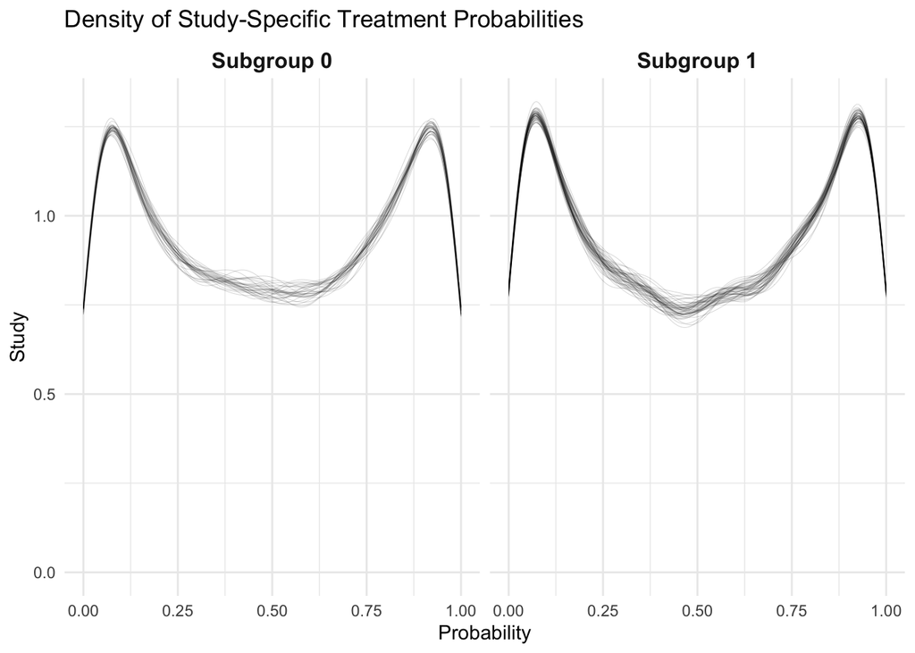

```r
ggplot(treatment_long, aes(x = Probability, group = Study)) +
  geom_density(alpha = 0.01, linewidth = 0.03) +
  labs(title = "Density of Study-Specific Treatment Probabilities",
       x = "Probability",
       y = "Study",
       fill = "Density") +
  theme_minimal() +
  scale_y_continuous(limits = c(0, NA)) +  # Ensure y-axis starts at 0
  facet_wrap(~Subgroup, ncol = 2) +
  theme(strip.text = element_text(size = 12, face = "bold"))
```